# Respondent Driven Sampling (RDS)

Ming Cao

January 22, 2016

主要的应用是利用社交网络对难接触人群（hard to reach population），比如性工作者，男同性恋和注射吸毒者，进行抽样调查其HIV感染率。在抽样调查中，最重要的一点是要保证样本对总体具有代表性，比如想知道全国的人均收入，就不能在北京金融街上随便找些人来问问。为了确保“随机性”，通常的做法是在与要调查的目的无关的东西（电话本或者身份证之类）里面产生一个随机数。然而对于那些“隐藏”人群，往往是大概有多少都不知道，更别提能被有效的调查到了：如果采用传统的采样方法，恐怕要找到一定数量携带HIV的男同性恋得是猴年马月的事了吧？

RDS是基于目标人群内部互相之间的关系网络来有效的采集样本。具体做法是首先找到几个种子（seed），一般6到10个即可，发给每人一些代金券（coupon），他们可以分给自己认识的同样属性的人，拿到券的人过来做调查，这第一波（wave）人同样得到一些可以分发的coupon，如此滚雪球一般，等到8到10个wave以后就已经积累了几百人了。

好，现在人倒是采集到了，问题也来了，这显然的不是一个随机抽样啊，简单地用有病人数/样本量的估计不就犯了前面说过的基本原则了吗？这就是统计学界最近二十年来一直研究的怎样通过一些调整来得出尽量无偏（unbiased）的估计量了。从(Heckathorn 1997)到(Gile and Handcock 2015)，给出了一些至少从理论和模拟（simulation）上可行的办法。

这个[网站](http://www.respondentdrivensampling.org/)是专门讲RDS的，不过貌似有点过时了，新的东西都在这个[R包](https://cran.r-project.org/web/packages/RDS/)里面

下面用一些经典案例来演示

```r
library(RDS)

data(faux)
RDS.I.estimates(rds.data=faux,outcome.variable='X')
```

```
## RDS-I Estimate for X
##      Estimate         95% Interval Design Effect Std. Error     N
## blue   0.3109 (  0.2681,   0.3537)          1.42     0.0219   118
## red    0.6891 (  0.6463,   0.7319)          1.42     0.0219   271
##                                                       Total   389
## * Using population size estimate: 1000
```

```r
RDS.II.estimates(rds.data=faux,outcome.variable='X')
```

```
## RDS-II Estimate for X
##      Estimate         95% Interval Design Effect Std. Error     N
## blue   0.3103 (  0.2500,   0.3707)          2.82     0.0308   118
## red    0.6897 (  0.6293,   0.7500)          2.82     0.0308   271
##                                                       Total   389
## * Using population size estimate: 1000
```

```r
RDS.SS.estimates(rds.data=faux,outcome.variable='X')
```

```
## Gile's SS Estimate for X
##      Estimate         95% Interval Design Effect Std. Error     N
## blue   0.3085 (  0.2533,   0.3637)          2.37     0.0282   118
## red    0.6915 (  0.6363,   0.7467)          2.37     0.0282   271
##                                                       Total   389
## * Using population size estimate: 1000
```

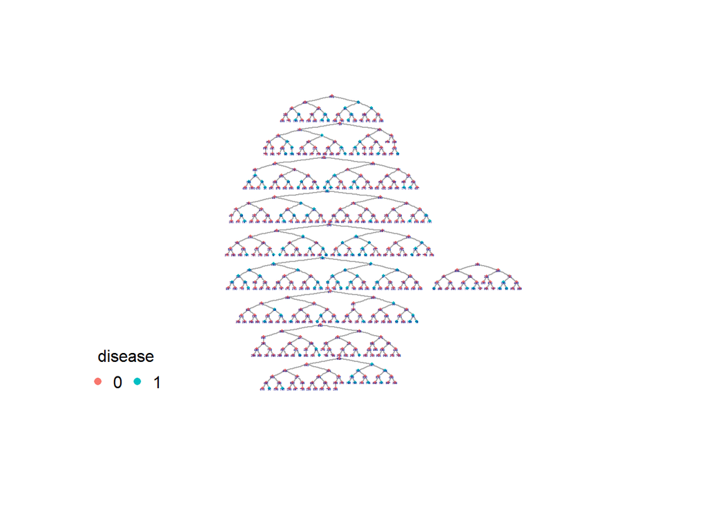

```r
data(fauxmadrona)
#bottleneck.plot(rds.data = fauxmadrona, outcome.variable = 'disease')
#plot(fauxmadrona)

#reingold.tilford.plot(faux)
reingold.tilford.plot(fauxmadrona,vertex.color="disease")
```

```r
#library(data.table)
```

关于实验设计和实施的细节可以参考WHO的这份[指南](http://applications.emro.who.int/dsaf/EMRPUB_2013_EN_1539.pdf)，Johns Hopkins的这个[slides](http://www.jhsph.edu/departments/population-family-and-reproductive-health/_docs/seminar-2012-10-31-rds.pdf)简明一些。

References

Gile, Krista J, and Mark S Handcock. 2015. “Network Model-Assisted Inference from Respondent-Driven Sampling Data.” *Journal of the Royal Statistical Society: Series A (Statistics in Society)* 178 (3). Wiley Online Library: 619–39.

Heckathorn, Douglas D. 1997. “Respondent-Driven Sampling: A New Approach to the Study of Hidden Populations.” *SOCIAL PROBLEMS-NEW YORK-* 44. University of California Press: 174–99.